# Analyse Tweets

Now that some tweets have been collected, I try to identify trends in the data.

Three correlations will be examined:

Is there a correlation between the sentiment of the tweets and the delay of the flight (flight number) mentioned in the tweet. It should be noted that it is not possible to determine which day the tweet refers to on the basis of the tweet text (in most cases, a flight with a specific flight number takes off on several days, it’s not possible to determine which day is meant).

Furthermore, I will be evaluating:

## Load Packages

```r
library(tidytext)
library(dplyr)
library(tidyr)
library(stringr)
library(tm)
library(SnowballC)
```

```r
library(sentimentr)
library(tidytext)
library(ggplot2)
library(forcats)
```

## Load Data

```r
departure_data <- read.csv("../datasets/departure_dataset.csv")
flight_tweets <- read.csv("../datasets/flight_tweets.csv")
```

## Code

### Remove Outliers

Since I want to use the flight delay data (`departure_data`), I remove outliers as I do with the notebooks that use the flight data from `flightera.com`.

```r
z_scores <- scale(departure_data$delay_departure_min)
z_threshold <- 3
outliers_departure_data<- abs(z_scores) > z_threshold
departure_data <- departure_data[!outliers_departure_data, ]
```

### Get Class Labels

Now I can get the median which will be used to split the data into two parts.

```r
category_names_quantiles <- c("ShortOrNoDelay", "LongDelay")
category_quantiles <- quantile(departure_data$delay_departure_min, probs = c(0.0, 0.5, 1.0))
category_quantiles
```

```
##   0%  50% 100%
## -116   13  157
```

### Select Tweets that are in German or English

I decided to only consider German and English tweets, as it would be difficult to apply all the necessary pre-processing steps in all the languages that occur. Considering tweets that are German or English, a large proportion of tweets are still considered.

```r
print(nrow(flight_tweets[flight_tweets$lang != "en" & flight_tweets$lang != "de",]))
```

```
## [1] 4640
```

```r
flight_tweets <- flight_tweets[flight_tweets$lang == "en" | flight_tweets$lang == "de",]
print(nrow(flight_tweets))
```

```
## [1] 12330
```

```r
head(flight_tweets)
```

```
##          username                                                  url
## 519         dokus          https://twitter.com/dokus/status/8897786636
## 520      bitslice      https://twitter.com/bitslice/status/12309824531
## 521      bitslice      https://twitter.com/bitslice/status/12319327217
## 522      bitslice      https://twitter.com/bitslice/status/12319528817
## 523    FlightSite    https://twitter.com/FlightSite/status/12452355056
## 524 suraseeonline https://twitter.com/suraseeonline/status/12506027025
##                          date
## 519 2010-02-10T11:27:19+00:00
## 520 2010-04-16T23:11:43+00:00
## 521 2010-04-17T02:37:37+00:00
## 522 2010-04-17T02:41:55+00:00
## 523 2010-04-19T12:15:44+00:00
## 524 2010-04-20T08:54:36+00:00
##                                                                                                      content
```

[output cut: 20 more lines]

### Remove Tweets

Apparently, there were some tweets collected for flight numbers BG1 and flight numbers starting with FX that were not related to the flight at all, but were related to an online game.

```r
head(flight_tweets[flight_tweets$flight_number == "BG1", ])
```

```
##           username                                                         url
## 1270 CaptainWabbit https://twitter.com/CaptainWabbit/status/924145572897886208
## 1416    arpa_assam    https://twitter.com/arpa_assam/status/928969543136944128
## 1457   Lobsterkun_   https://twitter.com/Lobsterkun_/status/930509854938226688
## 1463      Luisfius      https://twitter.com/Luisfius/status/930877494726574081
## 1494    mysticdrew    https://twitter.com/mysticdrew/status/932136744039755776
## 1686     Mivsan_NT     https://twitter.com/Mivsan_NT/status/939557441003499526
##                           date
## 1270 2017-10-28T05:27:29+00:00
## 1416 2017-11-10T12:56:13+00:00
## 1457 2017-11-14T18:56:52+00:00
## 1463 2017-11-15T19:17:44+00:00
## 1494 2017-11-19T06:41:32+00:00
## 1686 2017-12-09T18:08:44+00:00
##                                                                                                                                                                                                                                                           content
```

[output cut: 20 more lines]

I discovered that there are some keywords that are present when the tweet isn’t about the flight. It seemed to me that the most sensible approach would be to remove them based on the occurrence of such keywords. So let’s remove them:

```r
flight_tweets <- flight_tweets %>%
  filter(!((str_detect(content, regex("dnd", ignore_case = TRUE))
                                     | str_detect(content, regex("Baldur", ignore_case = TRUE))
                                     | str_detect(content, regex("trading", ignore_case = TRUE))
                                     | str_detect(content, regex("pinball", ignore_case = TRUE))
                                     | str_detect(content, regex("sony", ignore_case = TRUE))
                                     | str_detect(content, regex("Balder", ignore_case = TRUE))
                                     | str_detect(content, regex("Ball that started it all!", ignore_case = TRUE))
                                     | str_detect(content, regex("Claim FREE", ignore_case = TRUE)))))

head(flight_tweets[flight_tweets$flight_number == "BG1", ])
```

```
##          username                                                        url
## 763    arpa_assam   https://twitter.com/arpa_assam/status/928969543136944128
## 834    mysticdrew   https://twitter.com/mysticdrew/status/932136744039755776
## 1104  only4prabir  https://twitter.com/only4prabir/status/943482418283012096
## 1862 airportiacom https://twitter.com/airportiacom/status/978360957591343104
## 2156         sghs         https://twitter.com/sghs/status/993626169785364480
## 2565  davaeornlol https://twitter.com/davaeornlol/status/1013087328385011717
##                           date
## 763  2017-11-10T12:56:13+00:00
## 834  2017-11-19T06:41:32+00:00
## 1104 2017-12-20T14:05:12+00:00
## 1862 2018-03-26T20:00:04+00:00
## 2156 2018-05-07T22:58:34+00:00
## 2565 2018-06-30T15:50:15+00:00
##                                                                                                                                                                                                                                                     content
```

[output cut: 20 more lines]

### Remove Frequent Users

Some of the tweets were written by accounts that post tweets about flights in a partially automated way (i.e. status updates).

```r
flights_tweets_most_frequent_users <- flight_tweets %>%
  group_by(username) %>%
  summarize(count = n()) %>%
  arrange(desc(count))
head(flights_tweets_most_frequent_users, n=100)
```

```
## # A tibble: 100 × 2
##    username      count
##    <chr>         <int>
##  1 hkgarrivals     565
##  2 ClaimDelay      499
##  3 Skyaid2         321
##  4 LCYFlightInfo   250
##  5 aviation_graz   226
##  6 Flight_Patrol   225
##  7 dxbupdates      206
##  8 airportiacom    121
##  9 lufthansaNews   120
## 10 dougkempf       115
## # ℹ 90 more rows
```

Some of the tweets were written by accounts that tweet about flights in a partially automated way. Considering the accounts from which most of the tweets were written, I decided to exclude tweets from users who have posted at least 10 tweets.

```r
frequent_users <- flights_tweets_most_frequent_users %>%
  filter(count >= 10) %>%
  select(username)

flight_tweets <- anti_join(flight_tweets, frequent_users, by = "username")
print(nrow(flight_tweets))
```

```
## [1] 7046
```

```r
head(flight_tweets)
```

```
##        username                                                  url
## 1         dokus          https://twitter.com/dokus/status/8897786636
## 2      bitslice      https://twitter.com/bitslice/status/12309824531
## 3      bitslice      https://twitter.com/bitslice/status/12319327217
## 4      bitslice      https://twitter.com/bitslice/status/12319528817
## 5    FlightSite    https://twitter.com/FlightSite/status/12452355056
## 6 suraseeonline https://twitter.com/suraseeonline/status/12506027025
##                        date
## 1 2010-02-10T11:27:19+00:00
## 2 2010-04-16T23:11:43+00:00
## 3 2010-04-17T02:37:37+00:00
## 4 2010-04-17T02:41:55+00:00
## 5 2010-04-19T12:15:44+00:00
## 6 2010-04-20T08:54:36+00:00
##                                                                                                    content
## 1                                      And another gate change, delay currently 30min #kl1794 #klm #Munich
## 2           Further delay: TG970 to Zurich. Was just about to leave home for the airport when they called.
## 3 Latest update: TG916 to London and TG922 to Frankfurt resched to 1900. TG970 to Zurich under replanning.
## 4                              OK. TG970 to Zurich (the one delayed from Friday night) has been cancelled.
## 5                       SAA has cancelled flights from Europe: SA261 Frankfurt to JHB, SA265 Munich to JHB
## 6                                            Tg944,tg9309 to Rome operate tonight,and tg970 to zurich also
##   replyCount retweetCount likeCount quoteCount lang bookmarkCount flight_number
## 1          0            0         0          0   en             0        KL1794
## 2          0            0         0          0   en             0         TG970
## 3          0            0         0          0   en             0         TG970
## 4          0            0         0          0   en             0         TG970
## 5          0            0         0          0   en             0         SA265
## 6          0            0         0          0   en             0         TG970
```

### Dataset Exploration: Flights with the most tweets

Let’s take a look for which flight number the most tweets could be collected.

```r
flights_tweets_most_frequent_flight <- flight_tweets %>%
  group_by(flight_number) %>%
  summarize(count = n()) %>%
  arrange(desc(count))

head(flights_tweets_most_frequent_flight, n=20)
```

```
## # A tibble: 20 × 2
##    flight_number count
##    <chr>         <int>
##  1 AC837           453
##  2 A3803           323
##  3 AB6210          283
##  4 BA104           159
##  5 EK19            121
##  6 LH2222           99
##  7 UA83             94
##  8 FX3              88
##  9 LH762            84
## 10 LH2574           78
## 11 UA49             76
## 12 TG970            69
## 13 LH460            68
## 14 LH424            67
## 15 LH718            63
## 16 BA1402           62
## 17 LH458            60
## 18 LH766            56
## 19 LH714            55
## 20 LH452            50
```

### Calculate Average Delay for each Flight Number

```r
avg_delay_flight_number <- departure_data %>%
  group_by(flight_number) %>%
  summarize(avg_delay_min_flight_number = mean(delay_departure_min), count = n())
head(avg_delay_flight_number)
```

```
## # A tibble: 6 × 3
##   flight_number avg_delay_min_flight_number count
##   <chr>                               <dbl> <int>
## 1 0B186                                8.76    72
## 2 0B2986                              10.4     16
## 3 0B6885                              20        2
## 4 0B6886                              12.0    112
## 5 1T1138                               0        1
## 6 1T1922                               0        1
```

### Calculate Average Delay for each Flight Number in All Months

I want to assign a delay to each tweet. Based on the tweet text, I cannot tell to which flight on which day a tweet exactly refers and I have not collected flight data for all flights to be able to make an assignment here. Therefore, I always assign the average delay of the flights with the corresponding flight number to a tweet (each tweet is assigned to a flight number).

```r
avg_delay_flight_numbers_year_month <- departure_data %>%
  group_by(departure_scheduled_month_year_local, flight_number) %>%
  summarize(avg_delay_min_flight_number_year_month = mean(delay_departure_min))
```

```
## can override using the `.groups` argument.
```

```r
head(avg_delay_flight_numbers_year_month)
```

```
## # A tibble: 6 × 3
## # Groups:   departure_scheduled_month_year_local [1]
##   departure_scheduled_month_year_local flight_number avg_delay_min_flight_numb…¹
##   <chr>                                <chr>                               <dbl>
## 1 2017-10                              3O236                                24
## 2 2017-10                              4U4063                               29
## 3 2017-10                              4U4065                               15.5
## 4 2017-10                              4U4067                               36
## 5 2017-10                              5X6118                                0
## 6 2017-10                              A328                                  0
## # ℹ abbreviated name: ¹avg_delay_min_flight_number_year_month
```

It might occurs that there were no flights for a flight number in one of the months I am considering (10-2017 to 05-2023). In this case, I have decided to calculate the mean of the delay of the entire dataset but only considering the tweets with the corresponding flight number.

```r
# First, I create a dataframe that has one row for each month and each flight number.
flights_delay_statistics <- crossing(departure_scheduled_month_year_local = unique(avg_delay_flight_numbers_year_month$departure_scheduled_month_year_local),
                             flight_number = unique(avg_delay_flight_numbers_year_month$flight_number))
print(nrow(flights_delay_statistics))
```

```
## [1] 161908
```

```r
head(flights_delay_statistics)
```

```
## # A tibble: 6 × 2
##   departure_scheduled_month_year_local flight_number
##   <chr>                                <chr>
## 1 2017-10                              0B186
## 2 2017-10                              0B2986
## 3 2017-10                              0B6885
## 4 2017-10                              0B6886
## 5 2017-10                              1T1138
## 6 2017-10                              1T1922
```

```r
flights_delay_statistics <- flights_delay_statistics %>%
  left_join(avg_delay_flight_numbers_year_month, by = c("departure_scheduled_month_year_local", "flight_number"))

get_average_delay_of_flight_number <- function(flight_numbers) {
  # Add the average delay of a flight is no flight available in a month for a flight number
  avg_delays <- sapply(flight_numbers, function(flight_number) {
    avg_delay_flight_number[avg_delay_flight_number$flight_number == flight_number, ]$avg_delay_min_flight_number[1]
  })
  return(avg_delays)
}

flights_delay_statistics <- flights_delay_statistics %>%
  # avg_delay_min_flight_number_year_month is NA if there are no flights for a specifc flight number in a specifc month
  mutate(avg_delay_min_flight_number_year_month = ifelse(is.na(avg_delay_min_flight_number_year_month), get_average_delay_of_flight_number(flight_number), avg_delay_min_flight_number_year_month)) %>%
  mutate(delay_class_based_on_year_month_and_flight_number = cut(avg_delay_min_flight_number_year_month, breaks = category_quantiles, labels = category_names_quantiles, include.lowest = TRUE))
```

Now let’s add the calculated average delays to all tweets:

**Add delay of each flight number based on month/year**

```r
flight_tweets$departure_scheduled_month_year_local <- format(as.Date(flight_tweets$date), "%Y-%m")
flight_tweets <- inner_join(flight_tweets, flights_delay_statistics, by = c("flight_number", "departure_scheduled_month_year_local"))
head(flight_tweets)
```

```
##          username                                                           url
## 1 PabloGlezArango https://twitter.com/PabloGlezArango/status/914378109209731073
## 2   ArtoftheSkies   https://twitter.com/ArtoftheSkies/status/914464220707770369
## 3 bjoern_aigudewi https://twitter.com/bjoern_aigudewi/status/914493899183460352
## 4        JetFox90        https://twitter.com/JetFox90/status/914559863753265152
## 5    ayahuascaman    https://twitter.com/ayahuascaman/status/914768843586854912
## 6        thefalda        https://twitter.com/thefalda/status/914789560697094145
##                        date
## 1 2017-10-01T06:35:04+00:00
## 2 2017-10-01T12:17:14+00:00
## 3 2017-10-01T14:15:10+00:00
## 4 2017-10-01T18:37:17+00:00
## 5 2017-10-02T08:27:42+00:00
## 6 2017-10-02T09:50:01+00:00
##                                                                                                                                     content
```

[output cut: 27 more lines]

**Add delay of each flight number**

```r
flight_tweets <- inner_join(flight_tweets, avg_delay_flight_number, by = c("flight_number"))
head(flight_tweets)
```

```
##          username                                                           url
## 1 PabloGlezArango https://twitter.com/PabloGlezArango/status/914378109209731073
## 2   ArtoftheSkies   https://twitter.com/ArtoftheSkies/status/914464220707770369
## 3 bjoern_aigudewi https://twitter.com/bjoern_aigudewi/status/914493899183460352
## 4        JetFox90        https://twitter.com/JetFox90/status/914559863753265152
## 5    ayahuascaman    https://twitter.com/ayahuascaman/status/914768843586854912
## 6        thefalda        https://twitter.com/thefalda/status/914789560697094145
##                        date
## 1 2017-10-01T06:35:04+00:00
## 2 2017-10-01T12:17:14+00:00
## 3 2017-10-01T14:15:10+00:00
## 4 2017-10-01T18:37:17+00:00
## 5 2017-10-02T08:27:42+00:00
## 6 2017-10-02T09:50:01+00:00
##                                                                                                                                     content
```

[output cut: 34 more lines]

### Text Preprocessing

After adding the average delay of the corresponding flight number in the month in which the tweet was written to each tweet, one can see if there are correlations. First, I check the relationship between the sentiment of the tweets and the delay.

To identify the sentiment of a tweet, I use `sentimentr`. Before that, I delete URLs, apply lowercasing and remove punctuation and numbers.

```r
flight_tweets <- flight_tweets %>%
  mutate(content_cleaned = str_to_lower(content)) %>%
  mutate(content_cleaned = gsub("(https?:\\/\\/)?(www\\.)?(\\w)+(\\w|\\.|\\/)*\\.(\\w)+(\\w|\\.|\\/|\\?|\\=|\\&)*", "", content_cleaned)) %>%
  mutate(content_cleaned = removePunctuation(content_cleaned)) %>%
  mutate(content_cleaned = removeNumbers(content_cleaned)) %>%
  mutate(content_cleaned = ifelse(lang == "en", removeWords(content_cleaned, stopwords("en")), removeWords(content_cleaned, stopwords("de")))) %>%
  mutate(content_cleaned = stripWhitespace(content_cleaned)) %>%
  mutate(content_cleaned = ifelse(lang == "en", wordStem(content_cleaned, language = "english"), wordStem(content_cleaned, language = "german"))) %>%
  mutate(sentiment_score = sentiment(content_cleaned)$sentiment)
head(flight_tweets)
```

```
##          username                                                           url
## 1 PabloGlezArango https://twitter.com/PabloGlezArango/status/914378109209731073
## 2   ArtoftheSkies   https://twitter.com/ArtoftheSkies/status/914464220707770369
## 3 bjoern_aigudewi https://twitter.com/bjoern_aigudewi/status/914493899183460352
## 4        JetFox90        https://twitter.com/JetFox90/status/914559863753265152
## 5    ayahuascaman    https://twitter.com/ayahuascaman/status/914768843586854912
## 6        thefalda        https://twitter.com/thefalda/status/914789560697094145
##                        date
## 1 2017-10-01T06:35:04+00:00
## 2 2017-10-01T12:17:14+00:00
## 3 2017-10-01T14:15:10+00:00
## 4 2017-10-01T18:37:17+00:00
## 5 2017-10-02T08:27:42+00:00
## 6 2017-10-02T09:50:01+00:00
##                                                                                                                                     content
```

[output cut: 48 more lines]

### Analyse Correlations

#### RQ1: Sentiment of Tweet vs. Average Delay of Flight in Month (in Minutes)

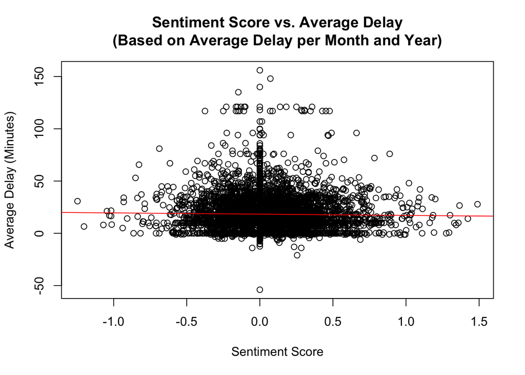

```r
plot(flight_tweets$sentiment_score, flight_tweets$avg_delay_min_flight_number_year_month, xlab = "Sentiment Score", ylab = "Average Delay (Minutes)", main = "Sentiment Score vs. Average Delay\n(Based on Average Delay per Month and Year)")
abline(lm(avg_delay_min_flight_number_year_month ~ sentiment_score, data = flight_tweets), col = "red")
```

Let’s calculate the Pearson correlation coefficient between the sentiment scores and average delay times. The correlation is not statistically significant (p-value = 0.1249), indicating that there is no strong linear relationship between the sentiment scores and average delay times.

```r
# t-test for correlation coefficients
correlation_test <- cor.test(flight_tweets$sentiment_score, flight_tweets$avg_delay_min_flight_number_year_month, method = "pearson")
correlation_test
```

```
##
##  Pearson's product-moment correlation
##
## data:  flight_tweets$sentiment_score and flight_tweets$avg_delay_min_flight_number_year_month
## t = -1.5347, df = 6742, p-value = 0.1249
## alternative hypothesis: true correlation is not equal to 0
## 95 percent confidence interval:
##  -0.042536369  0.005181586
## sample estimates:
##         cor
## -0.01868803
```

#### RQ2: Sentiment of Tweet vs. Average Delay of Flight (in Minutes)

Let’s calculate the Pearson correlation coefficient between the `sentiment_score` and `avg_delay_min_flight_number` variables. The correlation is not statistically significant (p-value = 0.9779), indicating that there is no significant relationship between the sentiment scores and average delay times.

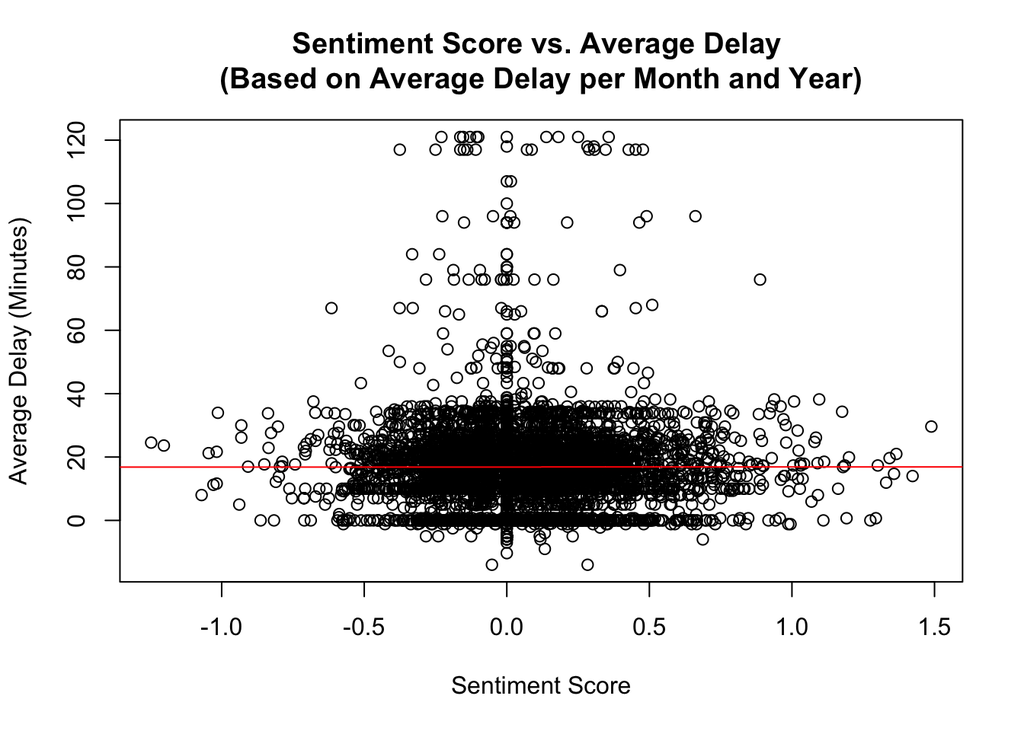

```r
plot(flight_tweets$sentiment_score, flight_tweets$avg_delay_min_flight_number, xlab = "Sentiment Score", ylab = "Average Delay (Minutes)", main = "Sentiment Score vs. Average Delay \n(Based on Average Delay per Month and Year)")
abline(lm(avg_delay_min_flight_number ~ sentiment_score, data = flight_tweets), col = "red")
```

```r
# t-test for correlation coefficients
correlation_test <- cor.test(flight_tweets$sentiment_score, flight_tweets$avg_delay_min_flight_number, method = "pearson")
correlation_test
```

```
##
##  Pearson's product-moment correlation
##
## data:  flight_tweets$sentiment_score and flight_tweets$avg_delay_min_flight_number
## t = 0.027688, df = 6742, p-value = 0.9779
## alternative hypothesis: true correlation is not equal to 0
## 95 percent confidence interval:
##  -0.02353029  0.02420432
## sample estimates:
##          cor
## 0.0003372027
```

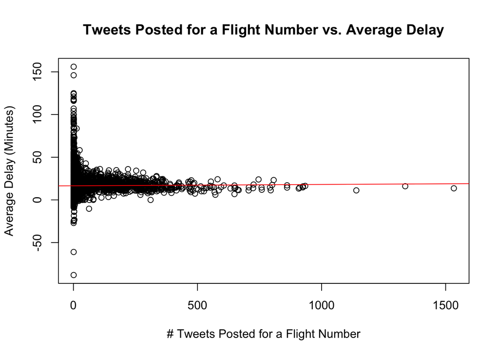

```r
correlation <- cor(avg_delay_flight_number$count, avg_delay_flight_number$avg_delay_min_flight_number, use = "complete.obs", method = "pearson")
plot(avg_delay_flight_number$count, avg_delay_flight_number$avg_delay_min_flight_number, xlab = "# Tweets Posted for a Flight Number", ylab = "Average Delay (Minutes)", main = "Tweets Posted for a Flight Number vs. Average Delay")
abline(lm(avg_delay_min_flight_number ~ count, data = avg_delay_flight_number), col = "red")
```

```r
correlation_test <- cor.test(avg_delay_flight_number$count, avg_delay_flight_number$avg_delay_min_flight_number, method = "pearson")
correlation_test
```

```
##
##  Pearson's product-moment correlation
##
## data:  avg_delay_flight_number$count and avg_delay_flight_number$avg_delay_min_flight_number
## t = 0.63616, df = 2379, p-value = 0.5247
## alternative hypothesis: true correlation is not equal to 0
## 95 percent confidence interval:
##  -0.02714323  0.05318434
## sample estimates:
##       cor
## 0.0130416
```

### Word Frequencies

Most frequent words

For the sake of completeness, you can also display which words occur very frequently in the tweets.

```r
all_tokens <- flight_tweets %>%
  unnest_tokens(word, content_cleaned)

word_frequencies <- all_tokens %>%
  count(word, sort = TRUE)

head(word_frequencies, n=40)
```

```
##              word    n
## 1              lh 3369
## 2          flight 3202
## 3       lufthansa 1899
## 4          munich 1254
## 5              ba  696
## 6             muc  597
## 7              ac  587
## 8         airport  585
## 9            flug  481
## 10    lufthansade  474
## 11              a  432
## 12             ua  425
## 13 britishairways  398
## 14            now  387
```

[output cut: 26 more lines]

You can also take a look at bigrammes.

```r
bigrams <- flight_tweets %>%
  unnest_tokens(bigram, content_cleaned, token = "ngrams", n = 2)

bigram_frequencies <- bigrams %>%
  count(bigram, sort = TRUE)

head(bigram_frequencies, n=40)
```

```
##                   bigram   n
## 1              flight lh 641
## 2              lh munich 361
## 3           lufthansa lh 264
## 4       lufthansa flight 163
## 5             air canada 161
## 6              flight ac 160
## 7            follow live 156
## 8               im board 156
## 9              live link 156
## 10               flug lh 143
## 11                lh muc 132
## 12             flight ba 127
## 13                 lh lh 127
## 14              board lh 108
```

[output cut: 26 more lines]

### Log Odds Ratio

Since it was not possible to identify a correlation, I will now use log odds ratio to see if there are tokens that occur particularly frequently in the ‘ShortOrNoDelay’ or ‘LongDelay’ class (seperated by Median before).

Source used: https://yalagiants.netlify.app/2019/07/log-odds-ratio-vs-tf-idf-vs-weighted-log-odds/ (see chapter “1. Log Odds Ratio”)

```r
# First, we need to calculate the frequency of each token within each of the two classes
word_freqs <- flight_tweets %>%
   unnest_tokens(word, content_cleaned) %>%
   count(delay_class_based_on_year_month_and_flight_number, word, sort = TRUE)

head(word_freqs)
```

```
##   delay_class_based_on_year_month_and_flight_number      word    n
## 1                                         LongDelay        lh 2479
## 2                                         LongDelay    flight 1818
## 3                                         LongDelay lufthansa 1435
## 4                                    ShortOrNoDelay    flight 1384
## 5                                    ShortOrNoDelay        lh  890
## 6                                         LongDelay    munich  865
```

```r
log_odds <- word_freqs %>%
  spread(delay_class_based_on_year_month_and_flight_number, n, fill = 0) %>%
  mutate_if(is.numeric, list(~ (. + 1) / (sum(. + 1)))) %>%
  mutate(logratio = log(ShortOrNoDelay / LongDelay)) %>%
  group_by(logratio > 0) %>%
  top_n(50, abs(logratio)) %>%
  ungroup() %>%
  mutate(word = fct_reorder(word, logratio))

head(log_odds)
```

```
## # A tibble: 6 × 5
##   word           ShortOrNoDelay LongDelay logratio `logratio > 0`
##   <fct>                   <dbl>     <dbl>    <dbl> <lgl>
## 1 abschied            0.000265  0.0000133     3.00 TRUE
## 2 abschiedsreise      0.000232  0.0000133     2.86 TRUE
## 3 airberlin           0.00310   0.000133      3.15 TRUE
## 4 airberlinflug       0.000564  0.0000133     3.75 TRUE
## 5 airfranceklm        0.000166  0.0000133     2.53 TRUE
## 6 airlinevideos       0.0000166 0.000120     -1.97 FALSE
```

If you look at the tokens with the highest or lowest log odds values, you can hardly see any words where you would assume that they indicate a lower/higher delay of departure. Among the terms with the lowest log odds values (red bars, class “LongDelay”), however, one can still find a few tokens, including “langste”, “helped”, “trotz”, although these primarily have a negative connotations and do not quite clearly refer to the topic of delayed departure.

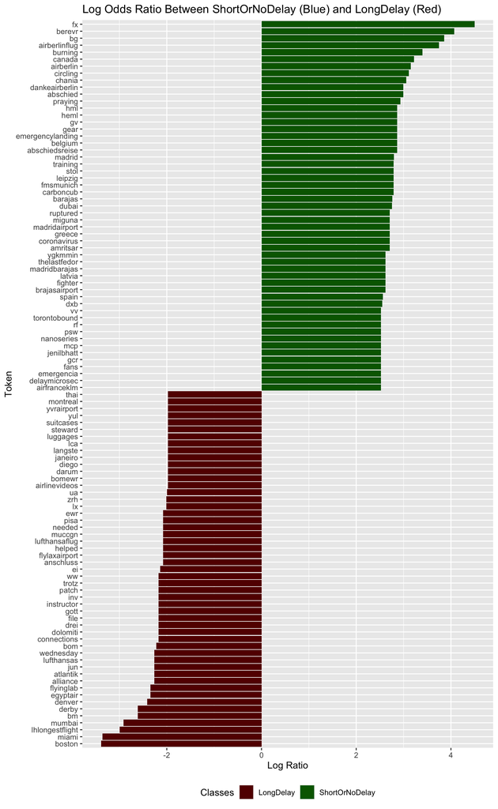

```r
# If logratio > 0, this means that the ratio of the probability of the word occurring in the "ShortOrNoDelay" category compared to the "LongDelay" category is positive.
plot_log_odds <- ggplot(log_odds, aes(word, logratio, fill = logratio > 0)) +
  geom_col() +
  coord_flip() +
  labs(
    title = "Log Odds Ratio Between ShortOrNoDelay (Blue) and LongDelay (Red)",
    x = "Token",
    y = "Log Ratio"
  ) +
  scale_fill_manual(values = c("TRUE" = "#006400", "FALSE" = "#640000"),
                    labels = c("LongDelay", "ShortOrNoDelay"),
                    name = "Classes") +
  theme(legend.position = "bottom")
plot_log_odds
```